# Risk Factor Analysis

## Outcome Variable

**Outcome Variable:** y_rate_len

## Predictor Variables

**Intervention Variable:** parity

**Adjustment Set:**

- arm
- W_mage
- meducyrs
- feducyrs
- W_mhtcm
- W_mwtkg
- W_mbmi
- vagbrth
- single
- delta_W_mage
- delta_meducyrs
- delta_feducyrs
- delta_W_mhtcm
- delta_W_mwtkg
- delta_W_mbmi
- delta_vagbrth
- delta_single

## Stratifying Variables

The analysis was stratified on these variable(s):

- agecat
- studyid
- country

## Data Summary

| agecat | studyid | country | parity | n_cell | n | outcome_variable |
| --- | --- | --- | --- | --- | --- | --- |
| 0-3 months | ki1000304b-SAS-CompFeed | INDIA | 1 | 344 | 1261 | y_rate_len |
| 0-3 months | ki1000304b-SAS-CompFeed | INDIA | 2 | 298 | 1261 | y_rate_len |
| 0-3 months | ki1000304b-SAS-CompFeed | INDIA | 3+ | 619 | 1261 | y_rate_len |
| 0-3 months | ki1017093b-PROVIDE | BANGLADESH | 1 | 242 | 640 | y_rate_len |
| 0-3 months | ki1017093b-PROVIDE | BANGLADESH | 2 | 226 | 640 | y_rate_len |
| 0-3 months | ki1017093b-PROVIDE | BANGLADESH | 3+ | 172 | 640 | y_rate_len |
| 0-3 months | ki1101329-Keneba | GAMBIA | 1 | 130 | 1145 | y_rate_len |
| 0-3 months | ki1101329-Keneba | GAMBIA | 2 | 113 | 1145 | y_rate_len |
| 0-3 months | ki1101329-Keneba | GAMBIA | 3+ | 902 | 1145 | y_rate_len |
| 0-3 months | ki1113344-GMS-Nepal | NEPAL | 1 | 137 | 509 | y_rate_len |
| 0-3 months | ki1113344-GMS-Nepal | NEPAL | 2 | 129 | 509 | y_rate_len |
| 0-3 months | ki1113344-GMS-Nepal | NEPAL | 3+ | 243 | 509 | y_rate_len |
| 0-3 months | ki1126311-ZVITAMBO | ZIMBABWE | 1 | 3100 | 7981 | y_rate_len |
| 0-3 months | ki1126311-ZVITAMBO | ZIMBABWE | 2 | 2478 | 7981 | y_rate_len |
| 0-3 months | ki1126311-ZVITAMBO | ZIMBABWE | 3+ | 2403 | 7981 | y_rate_len |
| 0-3 months | ki1135781-COHORTS | GUATEMALA | 1 | 93 | 728 | y_rate_len |
| 0-3 months | ki1135781-COHORTS | GUATEMALA | 2 | 111 | 728 | y_rate_len |
| 0-3 months | ki1135781-COHORTS | GUATEMALA | 3+ | 524 | 728 | y_rate_len |
| 0-3 months | ki1135781-COHORTS | INDIA | 1 | 671 | 4021 | y_rate_len |
| 0-3 months | ki1135781-COHORTS | INDIA | 2 | 1015 | 4021 | y_rate_len |
| 0-3 months | ki1135781-COHORTS | INDIA | 3+ | 2335 | 4021 | y_rate_len |
| 0-3 months | kiGH5241-JiVitA-3 | BANGLADESH | 1 | 6339 | 19879 | y_rate_len |
| 0-3 months | kiGH5241-JiVitA-3 | BANGLADESH | 2 | 6881 | 19879 | y_rate_len |
| 0-3 months | kiGH5241-JiVitA-3 | BANGLADESH | 3+ | 6659 | 19879 | y_rate_len |
| 3-6 months | ki1000304b-SAS-CompFeed | INDIA | 1 | 299 | 1124 | y_rate_len |
| 3-6 months | ki1000304b-SAS-CompFeed | INDIA | 2 | 261 | 1124 | y_rate_len |
| 3-6 months | ki1000304b-SAS-CompFeed | INDIA | 3+ | 564 | 1124 | y_rate_len |
| 3-6 months | ki1017093b-PROVIDE | BANGLADESH | 1 | 214 | 598 | y_rate_len |
| 3-6 months | ki1017093b-PROVIDE | BANGLADESH | 2 | 221 | 598 | y_rate_len |
| 3-6 months | ki1017093b-PROVIDE | BANGLADESH | 3+ | 163 | 598 | y_rate_len |

[output cut: 156 more lines]

The following strata were considered:

- agecat: 0-3 months, studyid: ki1000304b-SAS-CompFeed, country: INDIA
- agecat: 0-3 months, studyid: ki1017093b-PROVIDE, country: BANGLADESH
- agecat: 0-3 months, studyid: ki1101329-Keneba, country: GAMBIA
- agecat: 0-3 months, studyid: ki1113344-GMS-Nepal, country: NEPAL
- agecat: 0-3 months, studyid: ki1126311-ZVITAMBO, country: ZIMBABWE
- agecat: 0-3 months, studyid: ki1135781-COHORTS, country: GUATEMALA
- agecat: 0-3 months, studyid: ki1135781-COHORTS, country: INDIA
- agecat: 0-3 months, studyid: kiGH5241-JiVitA-3, country: BANGLADESH
- agecat: 12-15 months, studyid: ki1000304b-SAS-CompFeed, country: INDIA
- agecat: 12-15 months, studyid: ki1000304b-SAS-FoodSuppl, country: INDIA
- agecat: 12-15 months, studyid: ki1017093b-PROVIDE, country: BANGLADESH
- agecat: 12-15 months, studyid: ki1066203-TanzaniaChild2, country: TANZANIA, UNITED REPUBLIC OF
- agecat: 12-15 months, studyid: ki1101329-Keneba, country: GAMBIA
- agecat: 12-15 months, studyid: ki1113344-GMS-Nepal, country: NEPAL
- agecat: 12-15 months, studyid: ki1126311-ZVITAMBO, country: ZIMBABWE
- agecat: 12-15 months, studyid: ki1135781-COHORTS, country: GUATEMALA
- agecat: 15-18 months, studyid: ki1000304b-SAS-CompFeed, country: INDIA
- agecat: 15-18 months, studyid: ki1000304b-SAS-FoodSuppl, country: INDIA
- agecat: 15-18 months, studyid: ki1017093b-PROVIDE, country: BANGLADESH
- agecat: 15-18 months, studyid: ki1066203-TanzaniaChild2, country: TANZANIA, UNITED REPUBLIC OF
- agecat: 15-18 months, studyid: ki1101329-Keneba, country: GAMBIA
- agecat: 15-18 months, studyid: ki1113344-GMS-Nepal, country: NEPAL
- agecat: 15-18 months, studyid: ki1126311-ZVITAMBO, country: ZIMBABWE
- agecat: 15-18 months, studyid: ki1135781-COHORTS, country: GUATEMALA
- agecat: 18-21 months, studyid: ki1017093b-PROVIDE, country: BANGLADESH
- agecat: 18-21 months, studyid: ki1066203-TanzaniaChild2, country: TANZANIA, UNITED REPUBLIC OF
- agecat: 18-21 months, studyid: ki1101329-Keneba, country: GAMBIA
- agecat: 18-21 months, studyid: ki1113344-GMS-Nepal, country: NEPAL
- agecat: 18-21 months, studyid: ki1126311-ZVITAMBO, country: ZIMBABWE
- agecat: 18-21 months, studyid: ki1135781-COHORTS, country: GUATEMALA
- agecat: 21-24 months, studyid: ki1017093b-PROVIDE, country: BANGLADESH
- agecat: 21-24 months, studyid: ki1101329-Keneba, country: GAMBIA
- agecat: 21-24 months, studyid: ki1113344-GMS-Nepal, country: NEPAL
- agecat: 21-24 months, studyid: ki1126311-ZVITAMBO, country: ZIMBABWE
- agecat: 21-24 months, studyid: ki1135781-COHORTS, country: GUATEMALA
- agecat: 3-6 months, studyid: ki1000304b-SAS-CompFeed, country: INDIA
- agecat: 3-6 months, studyid: ki1017093b-PROVIDE, country: BANGLADESH
- agecat: 3-6 months, studyid: ki1066203-TanzaniaChild2, country: TANZANIA, UNITED REPUBLIC OF
- agecat: 3-6 months, studyid: ki1101329-Keneba, country: GAMBIA
- agecat: 3-6 months, studyid: ki1113344-GMS-Nepal, country: NEPAL
- agecat: 3-6 months, studyid: ki1126311-ZVITAMBO, country: ZIMBABWE
- agecat: 3-6 months, studyid: ki1135781-COHORTS, country: GUATEMALA
- agecat: 3-6 months, studyid: ki1135781-COHORTS, country: INDIA
- agecat: 3-6 months, studyid: kiGH5241-JiVitA-3, country: BANGLADESH
- agecat: 6-9 months, studyid: ki1000304b-SAS-CompFeed, country: INDIA
- agecat: 6-9 months, studyid: ki1000304b-SAS-FoodSuppl, country: INDIA
- agecat: 6-9 months, studyid: ki1017093b-PROVIDE, country: BANGLADESH
- agecat: 6-9 months, studyid: ki1066203-TanzaniaChild2, country: TANZANIA, UNITED REPUBLIC OF
- agecat: 6-9 months, studyid: ki1101329-Keneba, country: GAMBIA
- agecat: 6-9 months, studyid: ki1113344-GMS-Nepal, country: NEPAL
- agecat: 6-9 months, studyid: ki1126311-ZVITAMBO, country: ZIMBABWE
- agecat: 6-9 months, studyid: ki1135781-COHORTS, country: GUATEMALA
- agecat: 6-9 months, studyid: ki1135781-COHORTS, country: INDIA
- agecat: 9-12 months, studyid: ki1000304b-SAS-CompFeed, country: INDIA
- agecat: 9-12 months, studyid: ki1000304b-SAS-FoodSuppl, country: INDIA
- agecat: 9-12 months, studyid: ki1017093b-PROVIDE, country: BANGLADESH
- agecat: 9-12 months, studyid: ki1066203-TanzaniaChild2, country: TANZANIA, UNITED REPUBLIC OF
- agecat: 9-12 months, studyid: ki1101329-Keneba, country: GAMBIA
- agecat: 9-12 months, studyid: ki1113344-GMS-Nepal, country: NEPAL
- agecat: 9-12 months, studyid: ki1126311-ZVITAMBO, country: ZIMBABWE
- agecat: 9-12 months, studyid: ki1135781-COHORTS, country: GUATEMALA
- agecat: 9-12 months, studyid: ki1135781-COHORTS, country: INDIA

### Dropped Strata

Some strata were dropped due to rare outcomes:

- agecat: 6-9 months, studyid: ki1000304b-SAS-FoodSuppl, country: INDIA
- agecat: 9-12 months, studyid: ki1000304b-SAS-FoodSuppl, country: INDIA
- agecat: 12-15 months, studyid: ki1000304b-SAS-FoodSuppl, country: INDIA
- agecat: 15-18 months, studyid: ki1000304b-SAS-FoodSuppl, country: INDIA
- agecat: 18-21 months, studyid: ki1066203-TanzaniaChild2, country: TANZANIA, UNITED REPUBLIC OF

## Methods Detail

We’re interested in the causal parameters $E[Y_a]$ for all values of $a \in \mathcal{A}$. These parameters represent the mean outcome if, possibly contrary to fact, we intervened to set all units to have $A=a$. Under the randomization and positivity assumptions, these are identified by the statistical parameters $\psi_a=E_W[E_{Y|A,W}(Y|A=a,W)]$. In addition, we’re interested in the mean of $Y$, $E[Y]$ under no intervention (the observed mean). We will estimate these parameters by using SuperLearner to fit the relevant likelihood factors – $E_{Y|A,W}(Y|A=a,W)$ and $p(A=a|W)$, and then updating our likelihood fit using a joint TMLE.

For unadjusted analyses ($W=\{\}$), initial likelihoods were estimated using Lrnr_glm to estimate the simple $E(Y|A)$ and Lrnr_mean to estimate $p(A)$. For adjusted analyses, a small library containing Lrnr_glmnet, Lrnr_xgboost, and Lrnr_mean was used.

Having estimated these parameters, we will then use the delta method to estimate relative risks and attributable risks relative to a prespecified baseline level of $A$.

# Results Detail

## Results Plots

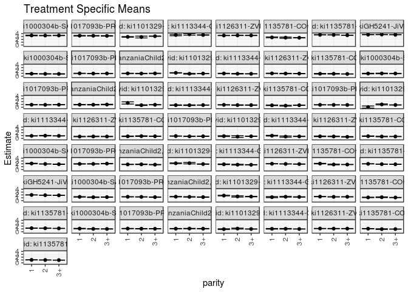

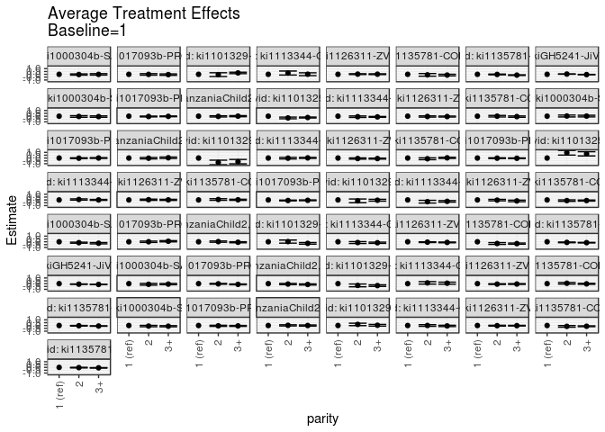

[figure not shown]

## Results Table

### Parameter: TSM

| agecat | studyid | country | intervention_level | baseline_level | estimate | ci_lower | ci_upper |
| --- | --- | --- | --- | --- | --- | --- | --- |
| 0-3 months | ki1000304b-SAS-CompFeed | INDIA | 1 | NA | 3.3784561 | 3.2634855 | 3.4934266 |
| 0-3 months | ki1000304b-SAS-CompFeed | INDIA | 2 | NA | 3.3436664 | 3.2740977 | 3.4132351 |
| 0-3 months | ki1000304b-SAS-CompFeed | INDIA | 3+ | NA | 3.3672111 | 3.3152451 | 3.4191771 |
| 0-3 months | ki1017093b-PROVIDE | BANGLADESH | 1 | NA | 3.2840316 | 3.1843786 | 3.3836846 |
| 0-3 months | ki1017093b-PROVIDE | BANGLADESH | 2 | NA | 3.2722526 | 3.1862285 | 3.3582767 |
| 0-3 months | ki1017093b-PROVIDE | BANGLADESH | 3+ | NA | 3.2324746 | 3.1490624 | 3.3158867 |
| 0-3 months | ki1101329-Keneba | GAMBIA | 1 | NA | 2.8726713 | 2.7637891 | 2.9815534 |
| 0-3 months | ki1101329-Keneba | GAMBIA | 2 | NA | 2.8152448 | 2.4987684 | 3.1317212 |
| 0-3 months | ki1101329-Keneba | GAMBIA | 3+ | NA | 3.1188807 | 3.0547027 | 3.1830586 |
| 0-3 months | ki1113344-GMS-Nepal | NEPAL | 1 | NA | 3.5207083 | 3.2860862 | 3.7553305 |
| 0-3 months | ki1113344-GMS-Nepal | NEPAL | 2 | NA | 3.7459219 | 3.4828256 | 4.0090183 |
| 0-3 months | ki1113344-GMS-Nepal | NEPAL | 3+ | NA | 3.5360933 | 3.4604288 | 3.6117578 |
| 0-3 months | ki1126311-ZVITAMBO | ZIMBABWE | 1 | NA | 3.3596483 | 3.3079361 | 3.4113605 |
| 0-3 months | ki1126311-ZVITAMBO | ZIMBABWE | 2 | NA | 3.3937121 | 3.3384737 | 3.4489506 |
| 0-3 months | ki1126311-ZVITAMBO | ZIMBABWE | 3+ | NA | 3.3817382 | 3.3337997 | 3.4296768 |
| 0-3 months | ki1135781-COHORTS | GUATEMALA | 1 | NA | 2.6927602 | 2.5646647 | 2.8208557 |
| 0-3 months | ki1135781-COHORTS | GUATEMALA | 2 | NA | 2.6005356 | 2.4050909 | 2.7959802 |
| 0-3 months | ki1135781-COHORTS | GUATEMALA | 3+ | NA | 2.5600275 | 2.5010313 | 2.6190238 |
| 0-3 months | ki1135781-COHORTS | INDIA | 1 | NA | 3.5926949 | 3.5437407 | 3.6416491 |
| 0-3 months | ki1135781-COHORTS | INDIA | 2 | NA | 3.5712477 | 3.5250277 | 3.6174677 |
| 0-3 months | ki1135781-COHORTS | INDIA | 3+ | NA | 3.4529047 | 3.4271928 | 3.4786166 |
| 0-3 months | kiGH5241-JiVitA-3 | BANGLADESH | 1 | NA | 3.6534936 | 3.6270047 | 3.6799824 |
| 0-3 months | kiGH5241-JiVitA-3 | BANGLADESH | 2 | NA | 3.6976866 | 3.6758716 | 3.7195017 |
| 0-3 months | kiGH5241-JiVitA-3 | BANGLADESH | 3+ | NA | 3.6026585 | 3.5801681 | 3.6251489 |
| 3-6 months | ki1000304b-SAS-CompFeed | INDIA | 1 | NA | 2.1034293 | 2.0199751 | 2.1868834 |
| 3-6 months | ki1000304b-SAS-CompFeed | INDIA | 2 | NA | 1.9427709 | 1.8961897 | 1.9893521 |
| 3-6 months | ki1000304b-SAS-CompFeed | INDIA | 3+ | NA | 1.8520406 | 1.7939749 | 1.9101062 |
| 3-6 months | ki1017093b-PROVIDE | BANGLADESH | 1 | NA | 1.9669161 | 1.8848802 | 2.0489520 |
| 3-6 months | ki1017093b-PROVIDE | BANGLADESH | 2 | NA | 1.9721596 | 1.8900013 | 2.0543179 |
| 3-6 months | ki1017093b-PROVIDE | BANGLADESH | 3+ | NA | 2.0613117 | 1.9858020 | 2.1368215 |

[output cut: 141 more lines]

### Parameter: E(Y)

| agecat | studyid | country | intervention_level | baseline_level | estimate | ci_lower | ci_upper |
| --- | --- | --- | --- | --- | --- | --- | --- |
| 0-3 months | ki1000304b-SAS-CompFeed | INDIA | NA | NA | 3.3515606 | 3.2984055 | 3.4047158 |
| 0-3 months | ki1017093b-PROVIDE | BANGLADESH | NA | NA | 3.2576810 | 3.2206777 | 3.2946843 |
| 0-3 months | ki1101329-Keneba | GAMBIA | NA | NA | 3.1106299 | 3.0607110 | 3.1605487 |
| 0-3 months | ki1113344-GMS-Nepal | NEPAL | NA | NA | 3.5989683 | 3.5479067 | 3.6500300 |
| 0-3 months | ki1126311-ZVITAMBO | ZIMBABWE | NA | NA | 3.3370118 | 3.3164684 | 3.3575551 |
| 0-3 months | ki1135781-COHORTS | GUATEMALA | NA | NA | 2.5828382 | 2.5396287 | 2.6260477 |
| 0-3 months | ki1135781-COHORTS | INDIA | NA | NA | 3.4951636 | 3.4771029 | 3.5132243 |
| 0-3 months | kiGH5241-JiVitA-3 | BANGLADESH | NA | NA | 3.6645220 | 3.6542864 | 3.6747577 |
| 3-6 months | ki1000304b-SAS-CompFeed | INDIA | NA | NA | 1.9406419 | 1.8967379 | 1.9845458 |
| 3-6 months | ki1017093b-PROVIDE | BANGLADESH | NA | NA | 1.9657457 | 1.9318660 | 1.9996254 |
| 3-6 months | ki1066203-TanzaniaChild2 | TANZANIA, UNITED REPUBLIC OF | NA | NA | 1.7960345 | 1.7599951 | 1.8320738 |
| 3-6 months | ki1101329-Keneba | GAMBIA | NA | NA | 1.9715566 | 1.9280386 | 2.0150747 |
| 3-6 months | ki1113344-GMS-Nepal | NEPAL | NA | NA | 1.7095685 | 1.6702436 | 1.7488934 |
| 3-6 months | ki1126311-ZVITAMBO | ZIMBABWE | NA | NA | 1.9753863 | 1.9557273 | 1.9950453 |
| 3-6 months | ki1135781-COHORTS | GUATEMALA | NA | NA | 1.7616932 | 1.7309393 | 1.7924472 |
| 3-6 months | ki1135781-COHORTS | INDIA | NA | NA | 1.8562696 | 1.8412447 | 1.8712944 |
| 3-6 months | kiGH5241-JiVitA-3 | BANGLADESH | NA | NA | 1.9202003 | 1.9097349 | 1.9306657 |
| 6-9 months | ki1000304b-SAS-CompFeed | INDIA | NA | NA | 1.2164378 | 1.1971945 | 1.2356811 |
| 6-9 months | ki1017093b-PROVIDE | BANGLADESH | NA | NA | 1.2824185 | 1.2571827 | 1.3076542 |
| 6-9 months | ki1066203-TanzaniaChild2 | TANZANIA, UNITED REPUBLIC OF | NA | NA | 1.3229826 | 1.2861186 | 1.3598466 |
| 6-9 months | ki1101329-Keneba | GAMBIA | NA | NA | 1.4249547 | 1.3698531 | 1.4800562 |
| 6-9 months | ki1113344-GMS-Nepal | NEPAL | NA | NA | 1.3172026 | 1.2765236 | 1.3578817 |
| 6-9 months | ki1126311-ZVITAMBO | ZIMBABWE | NA | NA | 1.3469775 | 1.3279219 | 1.3660330 |
| 6-9 months | ki1135781-COHORTS | GUATEMALA | NA | NA | 1.1069375 | 1.0799105 | 1.1339645 |
| 6-9 months | ki1135781-COHORTS | INDIA | NA | NA | 1.1876267 | 1.1734988 | 1.2017547 |
| 9-12 months | ki1000304b-SAS-CompFeed | INDIA | NA | NA | 0.9997324 | 0.9682232 | 1.0312416 |
| 9-12 months | ki1017093b-PROVIDE | BANGLADESH | NA | NA | 1.0499750 | 1.0230130 | 1.0769370 |
| 9-12 months | ki1066203-TanzaniaChild2 | TANZANIA, UNITED REPUBLIC OF | NA | NA | 1.0872065 | 1.0529274 | 1.1214857 |
| 9-12 months | ki1101329-Keneba | GAMBIA | NA | NA | 0.9677634 | 0.9232065 | 1.0123204 |
| 9-12 months | ki1113344-GMS-Nepal | NEPAL | NA | NA | 0.9983761 | 0.9658898 | 1.0308625 |
| 9-12 months | ki1126311-ZVITAMBO | ZIMBABWE | NA | NA | 1.0812148 | 1.0633428 | 1.0990869 |
| 9-12 months | ki1135781-COHORTS | GUATEMALA | NA | NA | 0.9507015 | 0.9262928 | 0.9751103 |
| 9-12 months | ki1135781-COHORTS | INDIA | NA | NA | 0.9788325 | 0.9636749 | 0.9939901 |
| 12-15 months | ki1000304b-SAS-CompFeed | INDIA | NA | NA | 0.8334688 | 0.7956713 | 0.8712664 |
| 12-15 months | ki1017093b-PROVIDE | BANGLADESH | NA | NA | 0.9597501 | 0.9335899 | 0.9859102 |
| 12-15 months | ki1066203-TanzaniaChild2 | TANZANIA, UNITED REPUBLIC OF | NA | NA | 0.9308176 | 0.8938698 | 0.9677654 |
| 12-15 months | ki1101329-Keneba | GAMBIA | NA | NA | 0.9311532 | 0.8983800 | 0.9639264 |
| 12-15 months | ki1113344-GMS-Nepal | NEPAL | NA | NA | 0.8797046 | 0.8507834 | 0.9086259 |
| 12-15 months | ki1126311-ZVITAMBO | ZIMBABWE | NA | NA | 0.9205920 | 0.8936831 | 0.9475009 |
| 12-15 months | ki1135781-COHORTS | GUATEMALA | NA | NA | 0.7856579 | 0.7592765 | 0.8120393 |
| 15-18 months | ki1000304b-SAS-CompFeed | INDIA | NA | NA | 0.9046837 | 0.8805433 | 0.9288241 |
| 15-18 months | ki1017093b-PROVIDE | BANGLADESH | NA | NA | 0.8560998 | 0.8320145 | 0.8801852 |
| 15-18 months | ki1066203-TanzaniaChild2 | TANZANIA, UNITED REPUBLIC OF | NA | NA | 0.9386381 | 0.8958056 | 0.9814706 |
| 15-18 months | ki1101329-Keneba | GAMBIA | NA | NA | 0.8874581 | 0.8529191 | 0.9219971 |
| 15-18 months | ki1113344-GMS-Nepal | NEPAL | NA | NA | 0.7549520 | 0.7202105 | 0.7896934 |
| 15-18 months | ki1126311-ZVITAMBO | ZIMBABWE | NA | NA | 0.7994243 | 0.7694755 | 0.8293732 |
| 15-18 months | ki1135781-COHORTS | GUATEMALA | NA | NA | 0.7458835 | 0.7161259 | 0.7756412 |
| 18-21 months | ki1017093b-PROVIDE | BANGLADESH | NA | NA | 0.8393377 | 0.8153485 | 0.8633269 |
| 18-21 months | ki1101329-Keneba | GAMBIA | NA | NA | 0.8148545 | 0.7779341 | 0.8517749 |
| 18-21 months | ki1113344-GMS-Nepal | NEPAL | NA | NA | 0.9038955 | 0.8699458 | 0.9378453 |
| 18-21 months | ki1126311-ZVITAMBO | ZIMBABWE | NA | NA | 0.6808824 | 0.6468583 | 0.7149065 |
| 18-21 months | ki1135781-COHORTS | GUATEMALA | NA | NA | 0.7491980 | 0.7206457 | 0.7777504 |
| 21-24 months | ki1017093b-PROVIDE | BANGLADESH | NA | NA | 0.7631391 | 0.7377453 | 0.7885328 |
| 21-24 months | ki1101329-Keneba | GAMBIA | NA | NA | 0.7279143 | 0.6917604 | 0.7640682 |
| 21-24 months | ki1113344-GMS-Nepal | NEPAL | NA | NA | 0.7990312 | 0.7536798 | 0.8443825 |
| 21-24 months | ki1126311-ZVITAMBO | ZIMBABWE | NA | NA | 0.6907415 | 0.6526782 | 0.7288047 |
| 21-24 months | ki1135781-COHORTS | GUATEMALA | NA | NA | 0.6777084 | 0.6544850 | 0.7009317 |

### Parameter: ATE

| agecat | studyid | country | intervention_level | baseline_level | estimate | ci_lower | ci_upper |
| --- | --- | --- | --- | --- | --- | --- | --- |
| 0-3 months | ki1000304b-SAS-CompFeed | INDIA | 1 | 1 | 0.0000000 | 0.0000000 | 0.0000000 |
| 0-3 months | ki1000304b-SAS-CompFeed | INDIA | 2 | 1 | -0.0347896 | -0.1420675 | 0.0724883 |
| 0-3 months | ki1000304b-SAS-CompFeed | INDIA | 3+ | 1 | -0.0112450 | -0.1329477 | 0.1104577 |
| 0-3 months | ki1017093b-PROVIDE | BANGLADESH | 1 | 1 | 0.0000000 | 0.0000000 | 0.0000000 |
| 0-3 months | ki1017093b-PROVIDE | BANGLADESH | 2 | 1 | -0.0117790 | -0.1435032 | 0.1199452 |
| 0-3 months | ki1017093b-PROVIDE | BANGLADESH | 3+ | 1 | -0.0515570 | -0.1814998 | 0.0783858 |
| 0-3 months | ki1101329-Keneba | GAMBIA | 1 | 1 | 0.0000000 | 0.0000000 | 0.0000000 |
| 0-3 months | ki1101329-Keneba | GAMBIA | 2 | 1 | -0.0574265 | -0.3911317 | 0.2762787 |
| 0-3 months | ki1101329-Keneba | GAMBIA | 3+ | 1 | 0.2462094 | 0.1202377 | 0.3721811 |
| 0-3 months | ki1113344-GMS-Nepal | NEPAL | 1 | 1 | 0.0000000 | 0.0000000 | 0.0000000 |
| 0-3 months | ki1113344-GMS-Nepal | NEPAL | 2 | 1 | 0.2252136 | -0.1289134 | 0.5793406 |
| 0-3 months | ki1113344-GMS-Nepal | NEPAL | 3+ | 1 | 0.0153850 | -0.2313059 | 0.2620759 |
| 0-3 months | ki1126311-ZVITAMBO | ZIMBABWE | 1 | 1 | 0.0000000 | 0.0000000 | 0.0000000 |
| 0-3 months | ki1126311-ZVITAMBO | ZIMBABWE | 2 | 1 | 0.0340638 | -0.0415255 | 0.1096531 |
| 0-3 months | ki1126311-ZVITAMBO | ZIMBABWE | 3+ | 1 | 0.0220899 | -0.0483360 | 0.0925158 |
| 0-3 months | ki1135781-COHORTS | GUATEMALA | 1 | 1 | 0.0000000 | 0.0000000 | 0.0000000 |
| 0-3 months | ki1135781-COHORTS | GUATEMALA | 2 | 1 | -0.0922246 | -0.3254342 | 0.1409849 |
| 0-3 months | ki1135781-COHORTS | GUATEMALA | 3+ | 1 | -0.1327327 | -0.2736346 | 0.0081692 |
| 0-3 months | ki1135781-COHORTS | INDIA | 1 | 1 | 0.0000000 | 0.0000000 | 0.0000000 |
| 0-3 months | ki1135781-COHORTS | INDIA | 2 | 1 | -0.0214472 | -0.0887783 | 0.0458839 |
| 0-3 months | ki1135781-COHORTS | INDIA | 3+ | 1 | -0.1397902 | -0.1950688 | -0.0845117 |
| 0-3 months | kiGH5241-JiVitA-3 | BANGLADESH | 1 | 1 | 0.0000000 | 0.0000000 | 0.0000000 |
| 0-3 months | kiGH5241-JiVitA-3 | BANGLADESH | 2 | 1 | 0.0441931 | 0.0113562 | 0.0770300 |
| 0-3 months | kiGH5241-JiVitA-3 | BANGLADESH | 3+ | 1 | -0.0508350 | -0.0851733 | -0.0164968 |
| 3-6 months | ki1000304b-SAS-CompFeed | INDIA | 1 | 1 | 0.0000000 | 0.0000000 | 0.0000000 |
| 3-6 months | ki1000304b-SAS-CompFeed | INDIA | 2 | 1 | -0.1606584 | -0.2512864 | -0.0700303 |
| 3-6 months | ki1000304b-SAS-CompFeed | INDIA | 3+ | 1 | -0.2513887 | -0.3703520 | -0.1324254 |
| 3-6 months | ki1017093b-PROVIDE | BANGLADESH | 1 | 1 | 0.0000000 | 0.0000000 | 0.0000000 |
| 3-6 months | ki1017093b-PROVIDE | BANGLADESH | 2 | 1 | 0.0052434 | -0.1109931 | 0.1214800 |
| 3-6 months | ki1017093b-PROVIDE | BANGLADESH | 3+ | 1 | 0.0943956 | -0.0174241 | 0.2062153 |

[output cut: 141 more lines]

### Parameter: PAR

| agecat | studyid | country | intervention_level | baseline_level | estimate | ci_lower | ci_upper |
| --- | --- | --- | --- | --- | --- | --- | --- |
| 0-3 months | ki1000304b-SAS-CompFeed | INDIA | 1 | NA | -0.0268954 | -0.1196184 | 0.0658276 |
| 0-3 months | ki1017093b-PROVIDE | BANGLADESH | 1 | NA | -0.0263506 | -0.1151723 | 0.0624712 |
| 0-3 months | ki1101329-Keneba | GAMBIA | 1 | NA | 0.2379586 | 0.1276164 | 0.3483008 |
| 0-3 months | ki1113344-GMS-Nepal | NEPAL | 1 | NA | 0.0782600 | -0.1454337 | 0.3019537 |
| 0-3 months | ki1126311-ZVITAMBO | ZIMBABWE | 1 | NA | -0.0226366 | -0.0704269 | 0.0251537 |
| 0-3 months | ki1135781-COHORTS | GUATEMALA | 1 | NA | -0.1099220 | -0.2364348 | 0.0165908 |
| 0-3 months | ki1135781-COHORTS | INDIA | 1 | NA | -0.0975313 | -0.1443745 | -0.0506881 |
| 0-3 months | kiGH5241-JiVitA-3 | BANGLADESH | 1 | NA | 0.0110285 | -0.0142517 | 0.0363086 |
| 3-6 months | ki1000304b-SAS-CompFeed | INDIA | 1 | NA | -0.1627874 | -0.2389551 | -0.0866197 |
| 3-6 months | ki1017093b-PROVIDE | BANGLADESH | 1 | NA | -0.0011704 | -0.0762342 | 0.0738934 |
| 3-6 months | ki1066203-TanzaniaChild2 | TANZANIA, UNITED REPUBLIC OF | 1 | NA | 0.0106290 | -0.0483371 | 0.0695951 |
| 3-6 months | ki1101329-Keneba | GAMBIA | 1 | NA | -0.2119031 | -0.3292145 | -0.0945917 |
| 3-6 months | ki1113344-GMS-Nepal | NEPAL | 1 | NA | -0.1211850 | -0.2203149 | -0.0220550 |
| 3-6 months | ki1126311-ZVITAMBO | ZIMBABWE | 1 | NA | -0.0412122 | -0.0811738 | -0.0012506 |
| 3-6 months | ki1135781-COHORTS | GUATEMALA | 1 | NA | -0.3031824 | -0.3968081 | -0.2095567 |
| 3-6 months | ki1135781-COHORTS | INDIA | 1 | NA | -0.1338923 | -0.1802089 | -0.0875757 |
| 3-6 months | kiGH5241-JiVitA-3 | BANGLADESH | 1 | NA | -0.0724106 | -0.1009024 | -0.0439188 |
| 6-9 months | ki1000304b-SAS-CompFeed | INDIA | 1 | NA | -0.0918903 | -0.1741819 | -0.0095986 |
| 6-9 months | ki1017093b-PROVIDE | BANGLADESH | 1 | NA | -0.0584772 | -0.1036248 | -0.0133296 |
| 6-9 months | ki1066203-TanzaniaChild2 | TANZANIA, UNITED REPUBLIC OF | 1 | NA | -0.0578185 | -0.1177825 | 0.0021455 |
| 6-9 months | ki1101329-Keneba | GAMBIA | 1 | NA | -0.3403994 | -0.4576583 | -0.2231406 |
| 6-9 months | ki1113344-GMS-Nepal | NEPAL | 1 | NA | 0.1053412 | -0.0656995 | 0.2763819 |
| 6-9 months | ki1126311-ZVITAMBO | ZIMBABWE | 1 | NA | -0.0568709 | -0.0973227 | -0.0164191 |
| 6-9 months | ki1135781-COHORTS | GUATEMALA | 1 | NA | -0.0151542 | -0.0972879 | 0.0669795 |
| 6-9 months | ki1135781-COHORTS | INDIA | 1 | NA | -0.0655521 | -0.1025210 | -0.0285832 |
| 9-12 months | ki1000304b-SAS-CompFeed | INDIA | 1 | NA | -0.0978955 | -0.1674081 | -0.0283829 |
| 9-12 months | ki1017093b-PROVIDE | BANGLADESH | 1 | NA | -0.0559490 | -0.1135975 | 0.0016996 |
| 9-12 months | ki1066203-TanzaniaChild2 | TANZANIA, UNITED REPUBLIC OF | 1 | NA | 0.0169933 | -0.0446038 | 0.0785905 |
| 9-12 months | ki1101329-Keneba | GAMBIA | 1 | NA | 0.0602618 | -0.0857453 | 0.2062690 |
| 9-12 months | ki1113344-GMS-Nepal | NEPAL | 1 | NA | -0.0295611 | -0.1325506 | 0.0734284 |
| 9-12 months | ki1126311-ZVITAMBO | ZIMBABWE | 1 | NA | -0.0389684 | -0.0825674 | 0.0046306 |
| 9-12 months | ki1135781-COHORTS | GUATEMALA | 1 | NA | -0.1122160 | -0.1735327 | -0.0508994 |
| 9-12 months | ki1135781-COHORTS | INDIA | 1 | NA | -0.0565538 | -0.0952026 | -0.0179051 |
| 12-15 months | ki1000304b-SAS-CompFeed | INDIA | 1 | NA | -0.0207765 | -0.1060809 | 0.0645280 |
| 12-15 months | ki1017093b-PROVIDE | BANGLADESH | 1 | NA | -0.0100553 | -0.0541508 | 0.0340403 |
| 12-15 months | ki1066203-TanzaniaChild2 | TANZANIA, UNITED REPUBLIC OF | 1 | NA | -0.0298004 | -0.0909400 | 0.0313392 |
| 12-15 months | ki1101329-Keneba | GAMBIA | 1 | NA | -0.2251102 | -0.2981029 | -0.1521175 |
| 12-15 months | ki1113344-GMS-Nepal | NEPAL | 1 | NA | -0.0658060 | -0.1344421 | 0.0028301 |
| 12-15 months | ki1126311-ZVITAMBO | ZIMBABWE | 1 | NA | -0.0462274 | -0.1094667 | 0.0170118 |
| 12-15 months | ki1135781-COHORTS | GUATEMALA | 1 | NA | -0.0554928 | -0.1610454 | 0.0500599 |
| 15-18 months | ki1000304b-SAS-CompFeed | INDIA | 1 | NA | -0.0100846 | -0.1193362 | 0.0991669 |
| 15-18 months | ki1017093b-PROVIDE | BANGLADESH | 1 | NA | -0.0314661 | -0.0773262 | 0.0143940 |
| 15-18 months | ki1066203-TanzaniaChild2 | TANZANIA, UNITED REPUBLIC OF | 1 | NA | 0.0212211 | -0.0537989 | 0.0962412 |
| 15-18 months | ki1101329-Keneba | GAMBIA | 1 | NA | -0.6295746 | -1.0081598 | -0.2509893 |
| 15-18 months | ki1113344-GMS-Nepal | NEPAL | 1 | NA | 0.0104658 | -0.0767509 | 0.0976824 |
| 15-18 months | ki1126311-ZVITAMBO | ZIMBABWE | 1 | NA | -0.0508725 | -0.1147523 | 0.0130072 |
| 15-18 months | ki1135781-COHORTS | GUATEMALA | 1 | NA | 0.0615607 | -0.0336030 | 0.1567244 |
| 18-21 months | ki1017093b-PROVIDE | BANGLADESH | 1 | NA | -0.0155811 | -0.0535981 | 0.0224358 |
| 18-21 months | ki1101329-Keneba | GAMBIA | 1 | NA | 0.7452992 | 0.3834475 | 1.1071509 |
| 18-21 months | ki1113344-GMS-Nepal | NEPAL | 1 | NA | 0.0234517 | -0.0504547 | 0.0973581 |
| 18-21 months | ki1126311-ZVITAMBO | ZIMBABWE | 1 | NA | 0.0355214 | -0.0356064 | 0.1066491 |
| 18-21 months | ki1135781-COHORTS | GUATEMALA | 1 | NA | 0.0267213 | -0.0616606 | 0.1151032 |
| 21-24 months | ki1017093b-PROVIDE | BANGLADESH | 1 | NA | -0.0516159 | -0.0957151 | -0.0075166 |
| 21-24 months | ki1101329-Keneba | GAMBIA | 1 | NA | -0.0615581 | -0.2165109 | 0.0933947 |
| 21-24 months | ki1113344-GMS-Nepal | NEPAL | 1 | NA | -0.1466659 | -0.2728311 | -0.0205008 |
| 21-24 months | ki1126311-ZVITAMBO | ZIMBABWE | 1 | NA | -0.0249080 | -0.1186130 | 0.0687969 |
| 21-24 months | ki1135781-COHORTS | GUATEMALA | 1 | NA | -0.0899911 | -0.1767601 | -0.0032221 |